# Fouille de données massives - Projet final

CASANOVA MARROQUIN Stephanya

03/12/2021

### **Données**

Le projet a été basé sur une base de données décrivant **6224 individus américains** décrits par 15 variables :

- **Age** : âge
- **CSP** : catégorie socio-professionnelle
- **ScoreDemo** : un score démographique
- **Diplome** : le type de diplôme
- **ScoreDiplome** : un score construit en fonction du type de diplôme
- **StatutMarital** : le statut marital
- **Profession** : la profession
- **SituationFamiliale** : la situation familiale
- **Ethnie** : l’origine ethnique
- **Genre** : le genre
- **Economies** : le montant des économies
- **Dettes** : le montant des dettes
- **HeureSemaine** : le nombre d’heures travaillées par semaine
- **PaysOrigine** : le pays d’origine
- **Revenus** : montant des revenus (supérieur ou inférieur à 50k$)

### **Import des données dans notre environnement**

Pour charger les données dans notre environnement, nous allons utiliser le commande :

```r
data = read.table("adult_sample.data",sep=",",header=TRUE,strip.white=TRUE,na.strings ="?", stringsAsFactors = TRUE)
```

Dans ce commande nous pouvons observer les parameters **sep** : référence au séparateur, **strip.white** : supprime les espaces en blanc après d’un séparateur, **na.strings**: sustitution d’un string pour NA et **stringsAsFactors**.

### **Travail effectué**

#### **1. Identification des valeurs nulls et imputation des valeurs**

Après d’avoir importé les données, nous allons identifier les valeur nulls et nous allons les imputer une valeur par defaut. Initialement, nous identifions les variables catégorielles et quantitatives :

```r
ind_categ_feature = c(2,4,6,7,8,9,10,14,15)
data_categ = data[, ind_categ_feature]
data_continuous = data [,-ind_categ_feature]
```

Avec le commande **summary()** nous allons regarder les détails des données :

```r
summary(data_categ)
```

```
##                CSP               Diplome                   StatutMarital
##  Private         :4301   HS-grad     :2003   Divorced             : 850
##  Self-emp-not-inc: 489   Some-college:1418   Married-AF-spouse    :   5
##  Local-gov       : 400   Bachelors   :1020   Married-civ-spouse   :2848
##  State-gov       : 242   Masters     : 324   Married-spouse-absent:  86
##  Self-emp-inc    : 229   Assoc-voc   : 271   Never-married        :2051
##  (Other)         : 175   11th        : 231   Separated            : 194
##  NA's            : 388   (Other)     : 957   Widowed              : 190
##            Profession        SituationFamiliale                Ethnie
##  Craft-repair   : 783   Husband       :2499     Amer-Indian-Eskimo:  63
##  Exec-managerial: 766   Not-in-family :1603     Asian-Pac-Islander: 189
##  Prof-specialty : 766   Other-relative: 188     Black             : 617
##  Sales          : 735   Own-child     : 972     Other             :  45
##  Adm-clerical   : 714   Unmarried     : 646     White             :5310
##  (Other)        :2071   Wife          : 316
##  NA's           : 389
##     Genre             PaysOrigine    Revenus
##  Female:2025   United-States:5561   <=50K:4715
##  Male  :4199   Mexico       : 126   >50K :1509
##                Canada       :  34
##                Germany      :  28
##                Philippines  :  28
##                (Other)      : 326
##                NA's         : 121
```

Dans cette information, nous pouvons observer que les variables **CSP, Profession et PaysOrigine** ont des valeurs **nulls**.

```r
attWithNA<-subset(data_categ, select=c(CSP, Profession, PaysOrigine))
summary(attWithNA)
```

```
##                CSP                 Profession          PaysOrigine
##  Private         :4301   Craft-repair   : 783   United-States:5561
##  Self-emp-not-inc: 489   Exec-managerial: 766   Mexico       : 126
##  Local-gov       : 400   Prof-specialty : 766   Canada       :  34
##  State-gov       : 242   Sales          : 735   Germany      :  28
##  Self-emp-inc    : 229   Adm-clerical   : 714   Philippines  :  28
##  (Other)         : 175   (Other)        :2071   (Other)      : 326
##  NA's            : 388   NA's           : 389   NA's         : 121
```

Ces valeurs nulls vont être remplacés par de valeurs aléatoires en fonction de la distribution de fréquences dans chaque attribut :

```r
naCSP=length(data_categ$CSP[is.na(data_categ$CSP)])
data_categ$CSP[is.na(data_categ$CSP)]=sample(levels(data_categ$CSP),naCSP,
prob=table(data_categ$CSP),replace=TRUE)
data_categ$CSP=as.factor(data_categ$CSP)

nbNA=length(data_categ$Profession[is.na(data_categ$Profession)])
data_categ$Profession[is.na(data_categ$Profession)]=sample(levels(data_categ$Profession),nbNA,
prob=table(data_categ$Profession),replace=TRUE)
data_categ$Profession=as.factor(data_categ$Profession)

nbNA=length(data_categ$PaysOrigine[is.na(data_categ$PaysOrigine)])
data_categ$PaysOrigine[is.na(data_categ$PaysOrigine)]=sample(levels(data_categ$PaysOrigine),nbNA,
prob=table(data_categ$PaysOrigine),replace=TRUE)
data_categ$PaysOrigine=as.factor(data_categ$PaysOrigine)
```

De nouveau **Summary** pour valider que effectivement les donnés ont été replacés :

```r
attWithNA<-subset(data_categ, select=c(CSP, Profession, PaysOrigine))
summary(attWithNA)
```

```
##                CSP                 Profession          PaysOrigine
##  Private         :4579   Craft-repair   : 844   United-States:5677
##  Self-emp-not-inc: 528   Exec-managerial: 826   Mexico       : 127
##  Local-gov       : 429   Prof-specialty : 821   Canada       :  34
##  State-gov       : 260   Sales          : 778   Germany      :  28
##  Self-emp-inc    : 243   Adm-clerical   : 773   Philippines  :  28
##  Federal-gov     : 183   Other-service  : 658   Puerto-Rico  :  22
##  (Other)         :   2   (Other)        :1524   (Other)      : 308
```

Maintenant, nous allons observer les détails des attributs quantitatives :

```r
summary(data_continuous)
```

```
##       Age          ScoreDemo        ScoreDiplome     Economies
##  Min.   :17.00   Min.   :  19302   Min.   : 1.00   Min.   :    0
##  1st Qu.:28.00   1st Qu.: 118253   1st Qu.: 9.00   1st Qu.:    0
##  Median :37.00   Median : 179312   Median :10.00   Median :    0
##  Mean   :38.62   Mean   : 191041   Mean   :10.06   Mean   : 1028
##  3rd Qu.:48.00   3rd Qu.: 241204   3rd Qu.:12.00   3rd Qu.:    0
##  Max.   :90.00   Max.   :1184622   Max.   :16.00   Max.   :99999
##      Dettes         HeureSemaine
##  Min.   :   0.00   Min.   : 1.00
##  1st Qu.:   0.00   1st Qu.:40.00
##  Median :   0.00   Median :40.00
##  Mean   :  89.81   Mean   :40.48
##  3rd Qu.:   0.00   3rd Qu.:45.00
##  Max.   :3004.00   Max.   :99.00
```

Dans les résultat, nous ne trouvons pas des valeurs nulls.

Nous allons supprimer la variable redondante ScoreDiplome puisque est le recodage de la variable Diplome :

```r
data_continuous$ScoreDiplome = NULL
```

#### **2. Analyse Factorielle**

Maintenant avec la data traitée, nous allons faire une analyse en composant principals sur les variables continues :

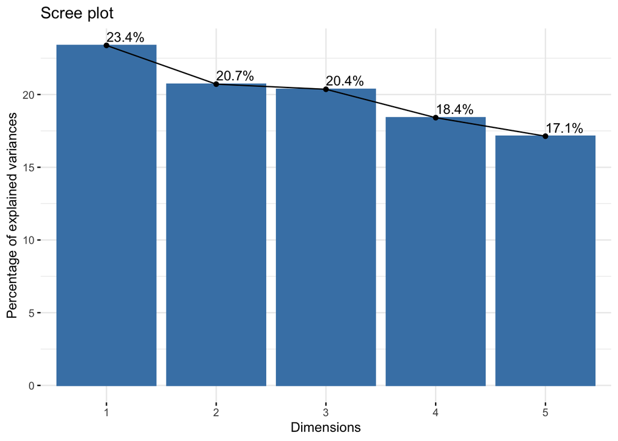

```r
res.pca <- PCA(data_continuous, graph = FALSE)
fviz_eig(res.pca, addlabels = TRUE)
```

Du graphique ci-dessus, nous observons que le 82.9% (> 72%) des informations (variances) contenues dans les données sont conservées par les quatre premières composantes principaux.

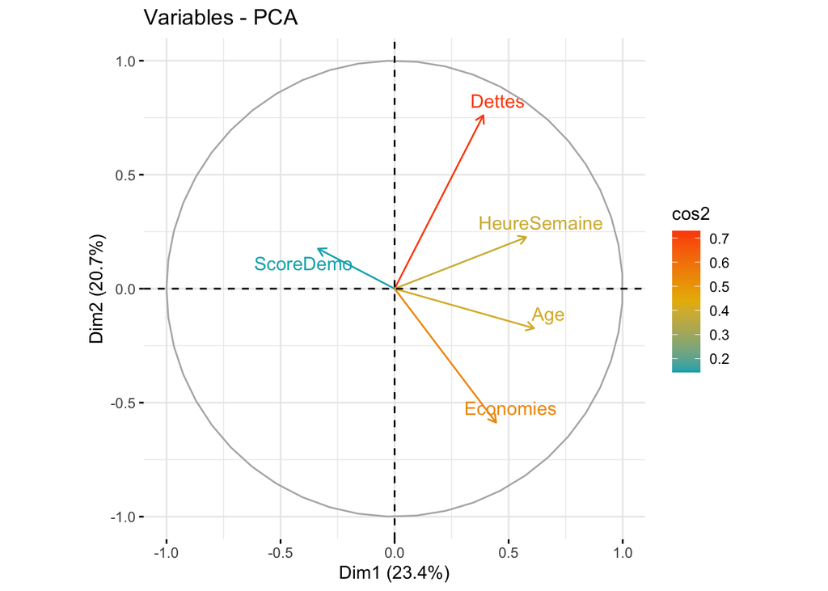

```r
# Colorer en fonction du cos2: qualité de représentation
fviz_pca_var(res.pca, col.var = "cos2",
             gradient.cols = c("#00AFBB", "#E7B800", "#FC4E07"),
             repel = TRUE # Évite le chevauchement de texte
             )
```

Le graphique de corrélation des variables ci-dessus montre les relations entre toutes les variables. Il peut être interprété comme suit:  
* Les variables : **Dettes et HeureSemaine** et **Age et Economies** sont positivement corrélées.  
* Les variables : **ScoreDemo et (Age, Economies)** sont négativement corrélées.  
* Les variables **ScoreDemo, Age et HeureSemaine** ne sont pas bien représentés pour l’ACP (cos2) à différence de **Dettes et Economies**

Maintenant, nous allons regarder la contribution de chaque variable aux axes principaux :

```r
res.pca$var$contrib
```

```
##                  Dim.1     Dim.2       Dim.3       Dim.4     Dim.5
## Age          31.965557  2.908096  7.80407230 40.28041948 17.041856
## ScoreDemo     9.649666  2.974066 56.24750717 26.77278503  4.355976
## Economies    16.927830 33.315762 19.02590595  0.09252983 30.637973
## Dettes       12.944193 55.874475  0.04812468  4.30854503 26.824662
## HeureSemaine 28.512754  4.927602 16.87438990 28.54572063 21.139533
```

Maintenant, pour les individus :

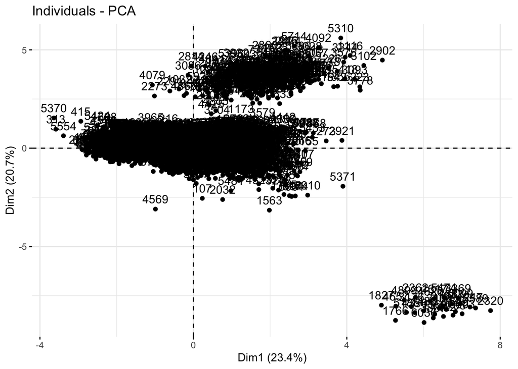

```r
fviz_pca_ind(res.pca)
```

Le graphique ci-dessus permet observer le comportement de chaque individu en considérant les variables : **age, economies, heureSemaine, dettes et scoreDemo**. Nous pouvons observer alors les gens ayant le plus de dettes et les plus d’heures travaillées en haut et les gens qui ont plus des economies et d’âge en bas. Le groupe en bas à droite représente un groupe avec des économies et des revenus élevés. Ces individus vont être mis de côté pour l’analyse.

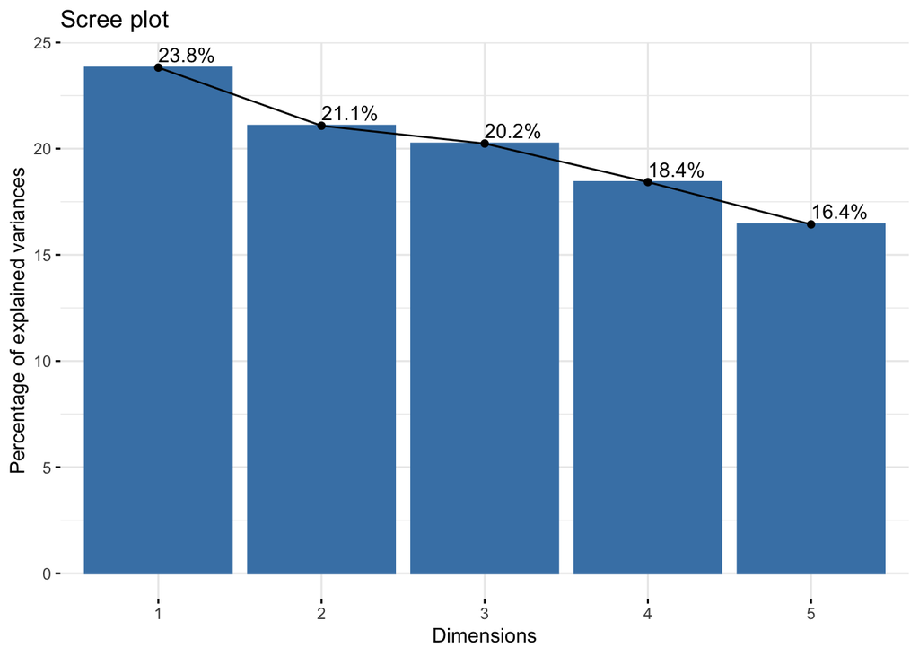

```r
data_categ$Economies = data_continuous$Economies
data_continuous<-filter(data_continuous, Economies != 99999)
data_categ<-filter(data_categ, Economies != 99999)
data_categ$Economies = NULL
res.pca <- PCA(data_continuous, graph = FALSE)
fviz_eig(res.pca, addlabels = TRUE)
```

Après d’avoir filtrés les individus avec **Economies** de 99999 :

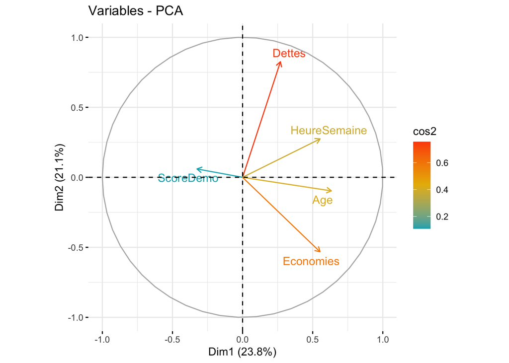

```r
fviz_pca_var(res.pca, col.var = "cos2",
             gradient.cols = c("#00AFBB", "#E7B800", "#FC4E07"),
             repel = TRUE # Évite le chevauchement de texte
             )
```

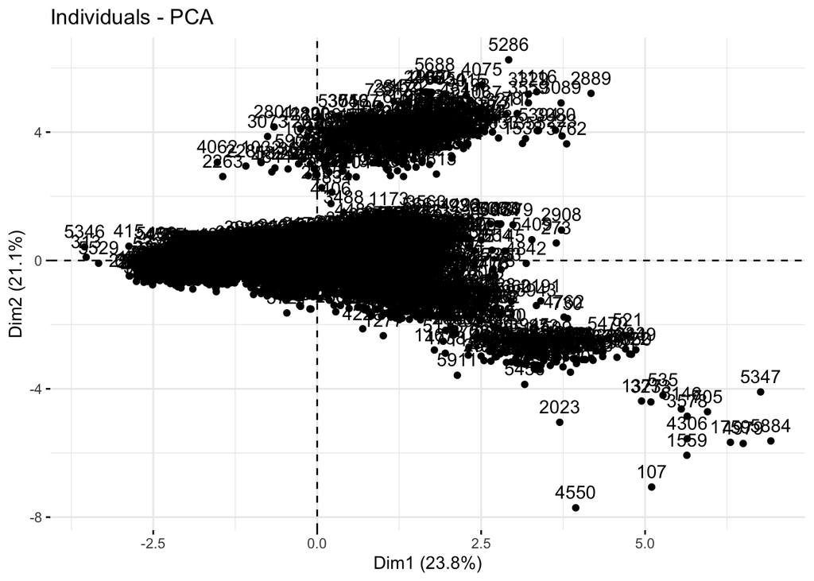

```r
fviz_pca_ind(res.pca)
```

#### **3. Clustering**

Comme les unités de mesure sont très différentes, nous allons normaliser les données :

```r
data_continuous2=scale(data_continuous)
```

Maintenant, nous allons utiliser l’inertie intra-classe pour choisir un nombre de clusters adéquat :

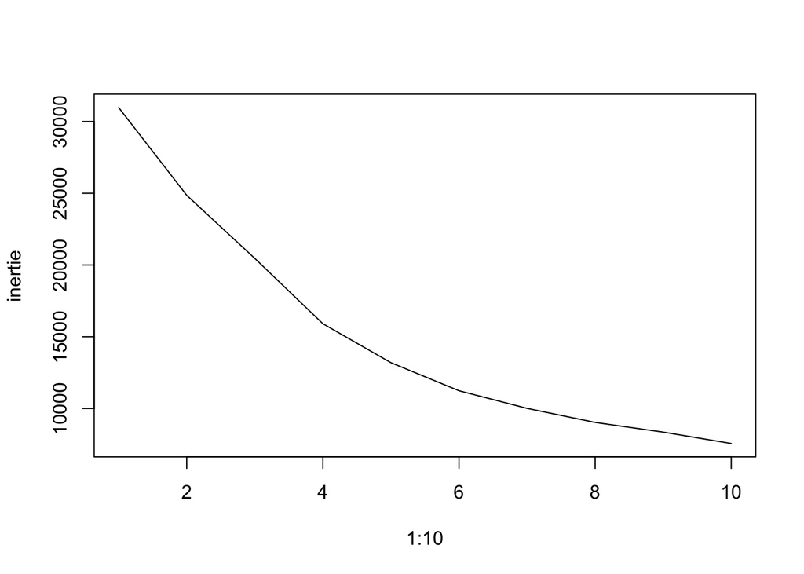

```r
inertie=c()
for (k in 1:10){
res=kmeans(data_continuous2,centers=k,nstart = 10)
inertie[k]=res$tot.withinss
}
plot(1:10,inertie,type='l')
```

Selon le graphique, nous allons choisir 4 clusters.

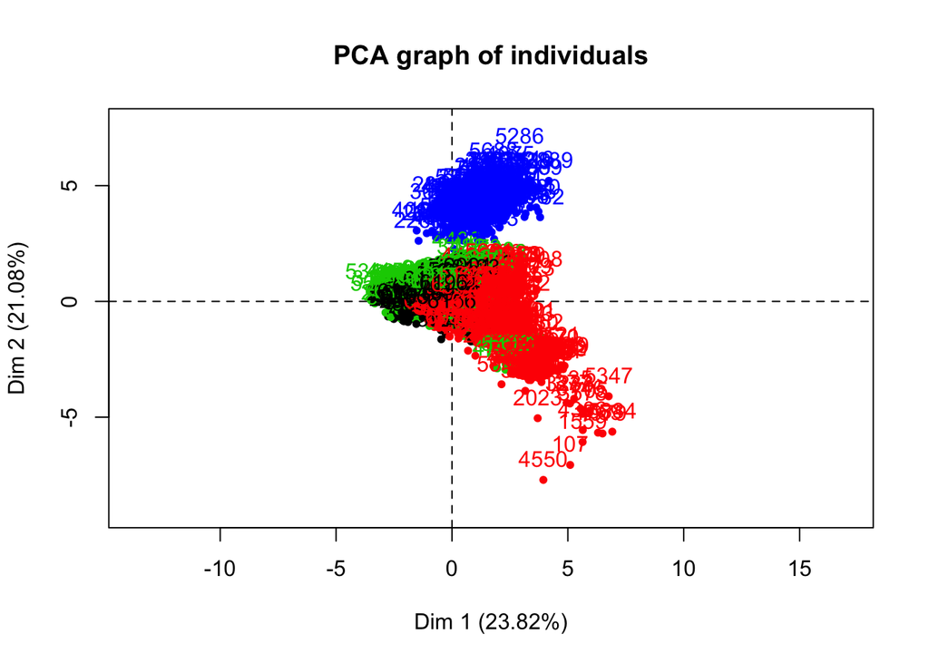

```r
res_ka=kmeans(data_continuous2,centers=4,nstart = 10)
res.pca <- PCA(data_continuous2, graph = FALSE)
plot(res.pca,choix = "ind",col.ind = res_ka$cluster,graph.type = "classic")
```

Ces 4 clusters pourraient correspondre à :  
* **Cluster axe 1 centre** = Les gens qui travaillent le plus  
* **Cluster axe 1 en haut** = Les gens avec plus de dettes  
* **Cluster axe 2 centre** = Les gens avec le scoreDemo plus haut  
* **Cluster axe 4** = Les gens avec plus des economies et agés

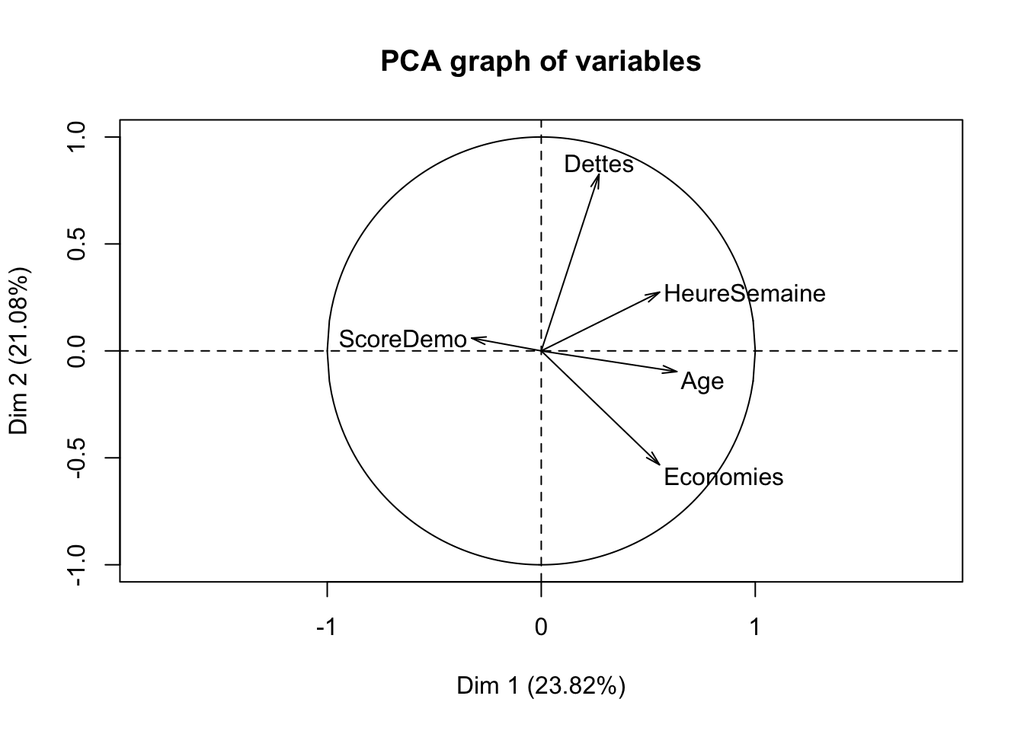

```r
plot(res.pca,choix = "var",graph.type = 'classic')
```

#### **4 Prediction**

**4.1 Ensemble d’entraînement et de testing**  
**4.2 Arbre de clasification**  
**4.3 Forêt aléatoire**

##### **4.1 Ensemble d’entraînement et de testing**

Pour la base de test, nous allons prendre 1000 individus au hasard :

```r
set.seed(1)
ind_test=sample(1:nrow(data_continuous),1000)
dco_test=data_continuous[ind_test,]
dco_app=data_continuous[-ind_test,]
dca_test=data_categ[ind_test,]
dca_app=data_categ[-ind_test,]
```

##### **4.2 Arbre de clasification**

Pour la classification, nous allons utiliser un arbre binaire sur les données quantitatives. Il faut alors utiliser un dataframe et rapatrier la variable à prédire **Revenus** dans le même dataframe que les variables quantitatives :

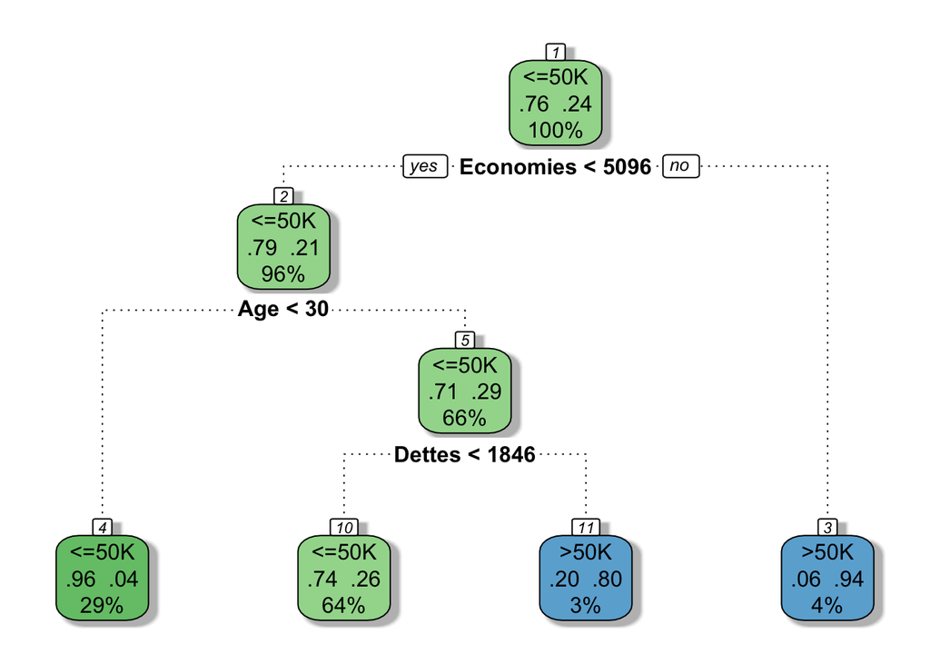

```r
dfco_app=data.frame(dco_app,Revenus=dca_app$Revenus)
mod2=rpart(Revenus~.,data=dfco_app)
p=predict(mod2,newdata = dco_test,type='class')
fancyRpartPlot(mod2,caption=NULL)
```

Pour évaluer les performances de l’arbre, nous allons observer le taux de bon classement et la matrice de confusion :

```r
mean(p==dca_test$Revenus)
```

```
## [1] 0.831
```

```r
table(p, dca_test$Revenus)
```

```
##
## p       <=50K >50K
##   <=50K   770  164
##   >50K      5   61
```

Maintenant, si nous voudrions considérer toutes les variables quantitatives et catégorielles :

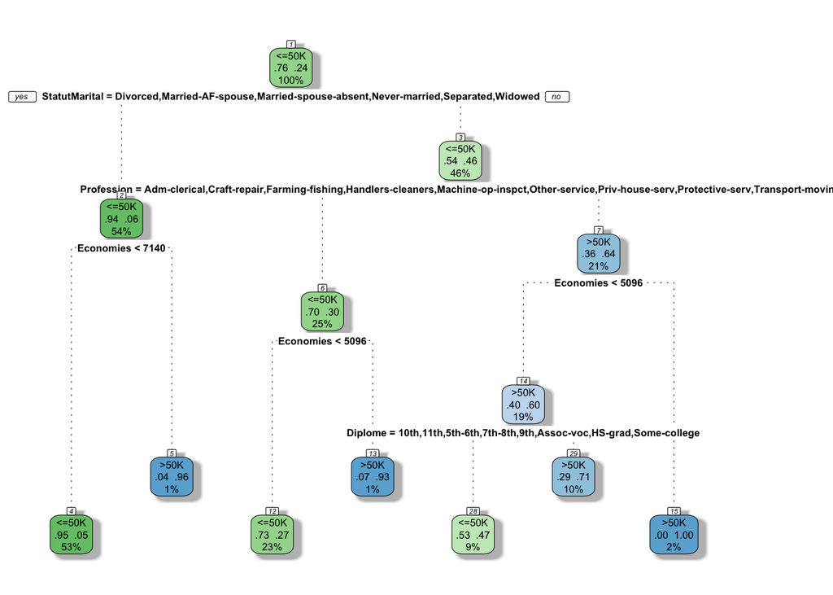

```r
app=cbind(dco_app,dca_app)
test=cbind(dco_test,dca_test)
mod3=rpart(Revenus~.,data=app)
p=predict(mod3,newdata = test,type='class')
fancyRpartPlot(mod3,caption=NULL)
```

Taux de bon classement et la matrice de confusion :

```r
mean(p==test$Revenus)
```

```
## [1] 0.841
```

```r
table(p, test$Revenus)
```

```
##
## p       <=50K >50K
##   <=50K   742  126
##   >50K     33   99
```

##### **4.3 Forêt aléatoire**

```r
set.seed(123)
mod4=randomForest(Revenus~.,data=app)
print(mod4)
```

```
##
## Call:
##  randomForest(formula = Revenus ~ ., data = app)
##                Type of random forest: classification
##                      Number of trees: 500
## No. of variables tried at each split: 3
##
##         OOB estimate of  error rate: 15.63%
## Confusion matrix:
##       <=50K >50K class.error
## <=50K  3609  331  0.08401015
## >50K    481  775  0.38296178
```

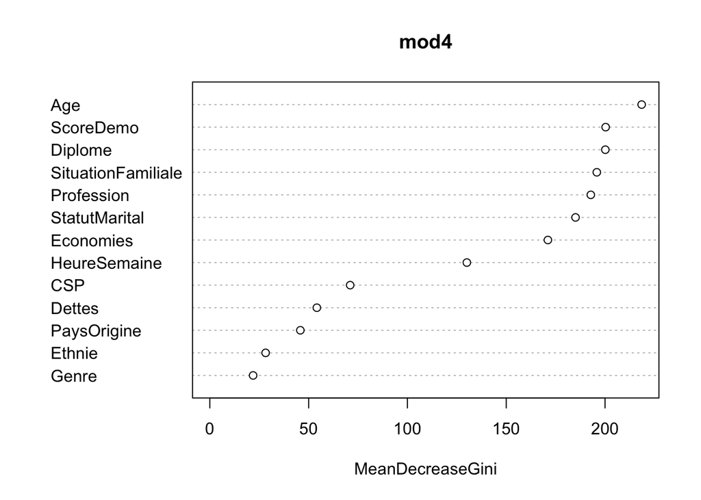

```r
varImpPlot(mod4)
```

Si nous voudrions choisir l’autre valeur de nTree, il faudrait choisir un nTree lorsque la valeur se stabilise au minimum :

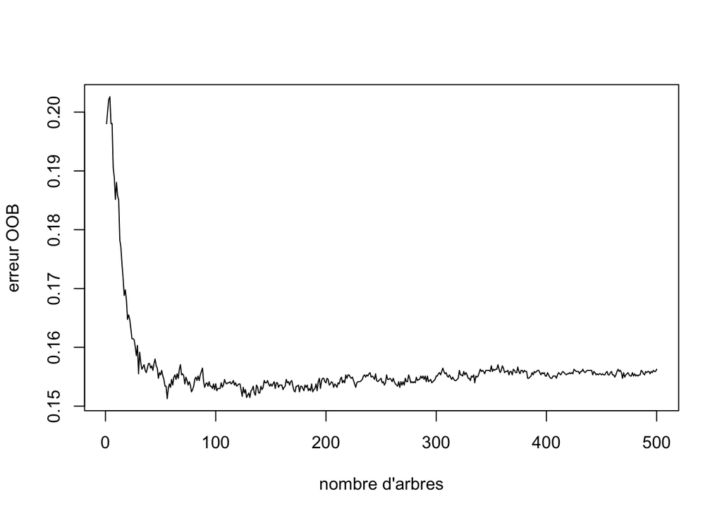

```r
plot(mod4$err.rate[, 1], type = "l", xlab = "nombre d'arbres", ylab = "erreur OOB")
```

```r
set.seed(123)
mod4 <-randomForest(Revenus~.,data=app, mtry=2, importance=TRUE,ntree=500)
print(mod4)
```

```
##
## Call:
##  randomForest(formula = Revenus ~ ., data = app, mtry = 2, importance = TRUE,      ntree = 500)
##                Type of random forest: classification
##                      Number of trees: 500
## No. of variables tried at each split: 2
##
##         OOB estimate of  error rate: 14.57%
## Confusion matrix:
##       <=50K >50K class.error
## <=50K  3673  267   0.0677665
## >50K    490  766   0.3901274
```

Maintenant, si nous faisons la prédiction avec le modèle amélioré :

```r
set.seed(123)
p=predict(mod4,newdata = test,type='class')
```

Nous obtenons un taux de bon classement et la matrice de confusion :

```r
mean(p==test$Revenus)
```

```
## [1] 0.838
```

```r
table(p, test$Revenus)
```

```
##
## p       <=50K >50K
##   <=50K   714  101
##   >50K     61  124
```

#### **Références**

Mars 14 2021  
http://www.sthda.com/french/wiki/fviz-pca-visualisation-de-l-analyse-en-composante-principale-logiciel-r-et-analyse-de-donn-es  
http://mehdikhaneboubi.free.fr/random_forest_r.html  
https://www.listendata.com/2014/11/random-forest-with-r.html